# Lab 5a - Foundations for statistical inference - Sampling distributions

Peter Gatica

03/14/2021

In this lab, you will investigate the ways in which the statistics from a random sample of data can serve as point estimates for population parameters. We’re interested in formulating a *sampling distribution* of our estimate in order to learn about the properties of the estimate, such as its distribution.

**Setting a seed:** We will take some random samples and build sampling distributions in this lab, which means you should set a seed at the start of your lab. If this concept is new to you, review the lab on probability.

## Getting Started

### Load packages

In this lab, we will explore and visualize the data using the **tidyverse** suite of packages. We will also use the **infer** package for resampling.

Let’s load the packages.

```r
library(tidyverse)
library(openintro)
library(infer)
```

### Creating a reproducible lab report

To create your new lab report, in RStudio, go to New File -> R Markdown… Then, choose From Template and then choose `Lab Report for OpenIntro Statistics Labs` from the list of templates.

### The data

A 2019 Gallup report states the following:

> The premise that scientific progress benefits people has been embodied in discoveries throughout the ages – from the development of vaccinations to the explosion of technology in the past few decades, resulting in billions of supercomputers now resting in the hands and pockets of people worldwide. Still, not everyone around the world feels science benefits them personally.

> **Source:** [World Science Day: Is Knowledge Power?](https://news.gallup.com/opinion/gallup/268121/world-science-day-knowledge-power.aspx)

The Wellcome Global Monitor finds that 20% of people globally do not believe that the work scientists do benefits people like them. In this lab, you will assume this 20% is a true population proportion and learn about how sample proportions can vary from sample to sample by taking smaller samples from the population. We will first create our population assuming a population size of 100,000. This means 20,000 (20%) of the population think the work scientists do does not benefit them personally and the remaining 80,000 think it does.

```r
global_monitor <- tibble(
  scientist_work = c(rep("Benefits", 80000), rep("Doesn't benefit", 20000))
)
```

The name of the data frame is `global_monitor` and the name of the variable that contains responses to the question *“Do you believe that the work scientists do benefit people like you?”* is `scientist_work`.

We can quickly visualize the distribution of these responses using a bar plot.

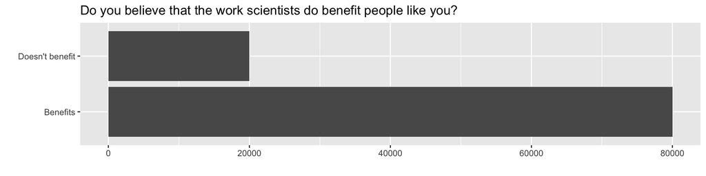

```r
ggplot(global_monitor, aes(x = scientist_work)) +
  geom_bar() +
  labs(
    x = "", y = "",
    title = "Do you believe that the work scientists do benefit people like you?"
  ) +
  coord_flip()
```

We can also obtain summary statistics to confirm we constructed the data frame correctly.

```r
global_monitor %>%
  count(scientist_work) %>%
  mutate(p = n /sum(n))
```

```
## # A tibble: 2 x 3
##   scientist_work      n     p
##   <chr>           <int> <dbl>
## 1 Benefits        80000   0.8
## 2 Doesn't benefit 20000   0.2
```

## The unknown sampling distribution

In this lab, you have access to the entire population, but this is rarely the case in real life. Gathering information on an entire population is often extremely costly or impossible. Because of this, we often take a sample of the population and use that to understand the properties of the population.

If you are interested in estimating the proportion of people who don’t think the work scientists do benefits them, you can use the `sample_n` command to survey the population.

```r
(samp1 <- global_monitor %>%
  sample_n(50))
```

```
## # A tibble: 50 x 1
##    scientist_work
##    <chr>
##  1 Benefits
##  2 Benefits
##  3 Benefits
##  4 Doesn't benefit
##  5 Doesn't benefit
##  6 Doesn't benefit
##  7 Benefits
##  8 Benefits
##  9 Benefits
## 10 Benefits
## # … with 40 more rows
```

This command collects a simple random sample of size 50 from the `global_monitor` dataset, and assigns the result to `samp1`. This is similar to randomly drawing names from a hat that contains the names of all in the population. Working with these 50 names is considerably simpler than working with all 100,000 people in the population.

1. Describe the distribution of responses in this sample. How does it compare to the distribution of responses in the population. **Hint:** Although the `sample_n` function takes a random sample of observations (i.e. rows) from the dataset, you can still refer to the variables in the dataset with the same names. Code you presented earlier for visualizing and summarising the population data will still be useful for the sample, however be careful to not label your proportion `p` since you’re now calculating a sample statistic, not a population parameters. You can customize the label of the statistics to indicate that it comes from the sample.

If you’re interested in estimating the proportion of all people who do not believe that the work scientists do benefits them, but you do not have access to the population data, your best single guess is the sample mean.

```r
samp1 %>%
  count(scientist_work) %>%
  mutate(p_hat = n /sum(n))
```

```
## # A tibble: 2 x 3
##   scientist_work      n p_hat
##   <chr>           <int> <dbl>
## 1 Benefits           37  0.74
## 2 Doesn't benefit    13  0.26
```

```r
# For use inline below
samp1_p_hat <- samp1 %>%
  count(scientist_work) %>%
  mutate(p_hat = n /sum(n)) %>%
  filter(scientist_work == "Doesn't benefit") %>%
  pull(p_hat) %>%
  round(2)
```

1. Would you expect the sample proportion to match the sample proportion of another student’s sample? Why, or why not? If the answer is no, would you expect the proportions to be somewhat different or very different? Ask a student team to confirm your answer.

   Answer: As expected sampl2 proportion was much different than the original with a samp2_phat of 0.16. As expected, the larger the sample size the closer the sample proportion gets to the population proportion of 20%

```r
(samp2 <- global_monitor %>%
  sample_n(50))
```

```
## # A tibble: 50 x 1
##    scientist_work
##    <chr>
##  1 Benefits
##  2 Benefits
##  3 Benefits
##  4 Doesn't benefit
##  5 Benefits
##  6 Benefits
##  7 Benefits
##  8 Benefits
##  9 Benefits
## 10 Benefits
## # … with 40 more rows
```

```r
samp2 %>%
  count(scientist_work) %>%
  mutate(p_hat = n /sum(n))
```

```
## # A tibble: 2 x 3
##   scientist_work      n p_hat
##   <chr>           <int> <dbl>
## 1 Benefits           42  0.84
## 2 Doesn't benefit     8  0.16
```

```r
# For use inline below
(samp2_p_hat <- samp2 %>%
  count(scientist_work) %>%
  mutate(p_hat = n /sum(n)) %>%
  filter(scientist_work == "Doesn't benefit") %>%
  pull(p_hat) %>%
  round(2))
```

```
## [1] 0.16
```

```r
(samp3 <- global_monitor %>%
  sample_n(100))
```

```
## # A tibble: 100 x 1
##    scientist_work
##    <chr>
##  1 Benefits
##  2 Benefits
##  3 Benefits
##  4 Benefits
##  5 Doesn't benefit
##  6 Benefits
##  7 Benefits
##  8 Doesn't benefit
##  9 Benefits
## 10 Benefits
## # … with 90 more rows
```

```r
samp3 %>%
  count(scientist_work) %>%
  mutate(p_hat = n /sum(n))
```

```
## # A tibble: 2 x 3
##   scientist_work      n p_hat
##   <chr>           <int> <dbl>
## 1 Benefits           81  0.81
## 2 Doesn't benefit    19  0.19
```

```r
# For use inline below
(samp3_p_hat <- samp3 %>%
  count(scientist_work) %>%
  mutate(p_hat = n /sum(n)) %>%
  filter(scientist_work == "Doesn't benefit") %>%
  pull(p_hat) %>%
  round(2))
```

```
## [1] 0.19
```

```r
(samp4 <- global_monitor %>%
  sample_n(1000))
```

```
## # A tibble: 1,000 x 1
##    scientist_work
##    <chr>
##  1 Benefits
##  2 Benefits
##  3 Benefits
##  4 Benefits
##  5 Benefits
##  6 Benefits
##  7 Benefits
##  8 Benefits
##  9 Benefits
## 10 Benefits
## # … with 990 more rows
```

```r
samp4 %>%
  count(scientist_work) %>%
  mutate(p_hat = n /sum(n))
```

```
## # A tibble: 2 x 3
##   scientist_work      n p_hat
##   <chr>           <int> <dbl>
## 1 Benefits          798 0.798
## 2 Doesn't benefit   202 0.202
```

```r
# For use inline below
(samp4_p_hat <- samp4 %>%
  count(scientist_work) %>%
  mutate(p_hat = n /sum(n)) %>%
  filter(scientist_work == "Doesn't benefit") %>%
  pull(p_hat) %>%
  round(2))
```

```
## [1] 0.2
```

Not surprisingly, every time you take another random sample, you might get a different sample proportion. It’s useful to get a sense of just how much variability you should expect when estimating the population mean this way. The distribution of sample proportions, called the *sampling distribution (of the proportion)*, can help you understand this variability. In this lab, because you have access to the population, you can build up the sampling distribution for the sample proportion by repeating the above steps many times. Here, we use R to take 15,000 different samples of size 50 from the population, calculate the proportion of responses in each sample, filter for only the *Doesn’t benefit* responses, and store each result in a vector called `sample_props50`. Note that we specify that `replace = TRUE` since sampling distributions are constructed by sampling with replacement.

```r
(sample_props50 <- global_monitor %>%
                    rep_sample_n(size = 50, reps = 15000, replace = TRUE) %>%
                    count(scientist_work) %>%
                    mutate(p_hat = n /sum(n)) %>%
                    filter(scientist_work == "Doesn't benefit"))
```

```
## # A tibble: 15,000 x 4
## # Groups:   replicate [15,000]
##    replicate scientist_work      n p_hat
##        <int> <chr>           <int> <dbl>
##  1         1 Doesn't benefit    10  0.2
##  2         2 Doesn't benefit    10  0.2
##  3         3 Doesn't benefit    13  0.26
##  4         4 Doesn't benefit    11  0.22
##  5         5 Doesn't benefit     5  0.1
##  6         6 Doesn't benefit    13  0.26
##  7         7 Doesn't benefit     8  0.16
##  8         8 Doesn't benefit    11  0.22
##  9         9 Doesn't benefit    14  0.28
## 10        10 Doesn't benefit    12  0.24
## # … with 14,990 more rows
```

And we can visualize the distribution of these proportions with a histogram.

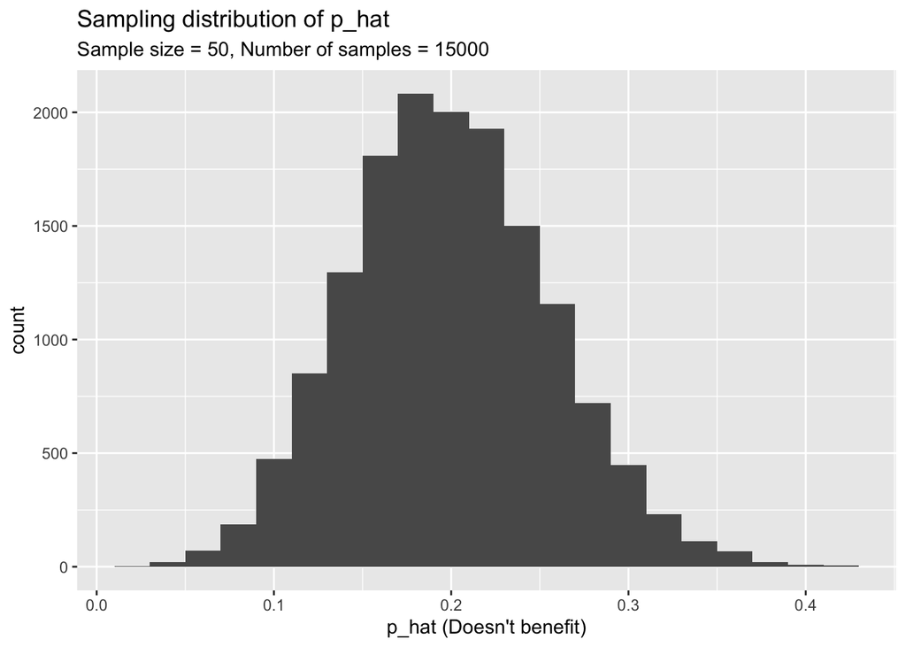

```r
ggplot(data = sample_props50, aes(x = p_hat)) +
  geom_histogram(binwidth = 0.02) +
  labs(
    x = "p_hat (Doesn't benefit)",
    title = "Sampling distribution of p_hat",
    subtitle = "Sample size = 50, Number of samples = 15000"
  )
```

Next, you will review how this set of code works.

1. How many elements are there in `sample_props50`? Describe the sampling distribution, and be sure to specifically note its center. Make sure to include a plot of the distribution in your answer.

   Answer: There are 15,000 samplings of size 50 with replacement in the sampling distribution. The center of the distribution is .2, same as the population proportion of 20%. The spread or standard error of .05. The shape of the sample distribution is symmetric and bell-shaped that it resembles a normal distribution.

## Interlude: Sampling distributions

The idea behind the `rep_sample_n` function is *repetition*. Earlier, you took a single sample of size `n` (50) from the population of all people in the population. With this new function, you can repeat this sampling procedure `rep` times in order to build a distribution of a series of sample statistics, which is called the **sampling distribution**.

Note that in practice one rarely gets to build true sampling distributions, because one rarely has access to data from the entire population.

Without the `rep_sample_n` function, this would be painful. We would have to manually run the following code 15,000 times

```r
global_monitor %>%
  sample_n(size = 50, replace = TRUE) %>%
  count(scientist_work) %>%
  mutate(p_hat = n /sum(n)) %>%
  filter(scientist_work == "Doesn't benefit")
```

```
## # A tibble: 1 x 3
##   scientist_work      n p_hat
##   <chr>           <int> <dbl>
## 1 Doesn't benefit    11  0.22
```

as well as store the resulting sample proportions each time in a separate vector.

Note that for each of the 15,000 times we computed a proportion, we did so from a **different** sample!

1. To make sure you understand how sampling distributions are built, and exactly what the `rep_sample_n` function does, try modifying the code to create a sampling distribution of **25 sample proportions** from **samples of size 10**, and put them in a data frame named `sample_props_small`. Print the output. How many observations are there in this object called `sample_props_small`? What does each observation represent?

```r
(sample_props_small <- global_monitor %>%
                    rep_sample_n(size = 10, reps = 25, replace = TRUE) %>%
                    count(scientist_work) %>%
                    mutate(p_hat = n /sum(n)) %>%
                    filter(scientist_work == "Doesn't benefit"))
```

```
## # A tibble: 22 x 4
## # Groups:   replicate [22]
##    replicate scientist_work      n p_hat
##        <int> <chr>           <int> <dbl>
##  1         1 Doesn't benefit     2   0.2
##  2         2 Doesn't benefit     4   0.4
##  3         3 Doesn't benefit     5   0.5
##  4         5 Doesn't benefit     2   0.2
##  5         6 Doesn't benefit     1   0.1
##  6         7 Doesn't benefit     5   0.5
##  7         9 Doesn't benefit     1   0.1
##  8        10 Doesn't benefit     1   0.1
##  9        11 Doesn't benefit     2   0.2
## 10        12 Doesn't benefit     4   0.4
## # … with 12 more rows
```

## Sample size and the sampling distribution

Mechanics aside, let’s return to the reason we used the `rep_sample_n` function: to compute a sampling distribution, specifically, the sampling distribution of the proportions from samples of 50 people.

```r
ggplot(data = sample_props50, aes(x = p_hat)) +
  geom_histogram(binwidth = 0.02)
```

[output not shown]

The sampling distribution that you computed tells you much about estimating the true proportion of people who think that the work scientists do doesn’t benefit them. Because the sample proportion is an unbiased estimator, the sampling distribution is centered at the true population proportion, and the spread of the distribution indicates how much variability is incurred by sampling only 50 people at a time from the population.

In the remainder of this section, you will work on getting a sense of the effect that sample size has on your sampling distribution.

1. Use the app below to create sampling distributions of proportions of *Doesn’t benefit* from samples of size 10, 50, and 100. Use 5,000 simulations. What does each observation in the sampling distribution represent?

   Answer: Each observation represents sample proportion of “Doesn’t benefit” responses.

   How does the mean, standard error, and shape of the sampling distribution change as the sample size increases?

   Answer: As the sample size increases the mean gets closer to the population proportion of 20% and the standard error gets smaller and the shape of the sample distribution resembles more of a normal distribution.

   How (if at all) do these values change if you increase the number of simulations? (You do not need to include plots in your answer.)

   Answer: For each of the sample sizes, increasing the number of simulations does not change the sample proportion, the standard error nor the shape of the sample distribution.

## More Practice

So far, you have only focused on estimating the proportion of those you think the work scientists doesn’t benefit them. Now, you’ll try to estimate the proportion of those who think it does.

Note that while you might be able to answer some of these questions using the app, you are expected to write the required code and produce the necessary plots and summary statistics. You are welcome to use the app for exploration.

1. Take a sample of size 15 from the population and calculate the proportion of people in this sample who think the work scientists do enhances their lives. Using this sample, what is your best point estimate of the population proportion of people who think the work scientists do enhances their lives?

   Answer: From this first sample, it appears from this simulation that the best point estimate of the population proportion of the people who think the work scientists do enhance their lives is 100%. However, if I run a second sample, I get a sample proportion of 87%. This seems like a most best estimate of the population proportion.

```r
(samp15 <- global_monitor %>%
  sample_n(15))
```

```
## # A tibble: 15 x 1
##    scientist_work
##    <chr>
##  1 Benefits
##  2 Benefits
##  3 Benefits
##  4 Benefits
##  5 Benefits
##  6 Benefits
##  7 Benefits
##  8 Benefits
##  9 Benefits
## 10 Benefits
## 11 Benefits
## 12 Benefits
## 13 Benefits
## 14 Benefits
## 15 Benefits
```

```r
samp15 %>%
  count(scientist_work) %>%
  mutate(p_hat = n /sum(n))
```

```
## # A tibble: 1 x 3
##   scientist_work     n p_hat
##   <chr>          <int> <dbl>
## 1 Benefits          15     1
```

```r
# For use inline below
(samp15_p_hat <- samp15 %>%
  count(scientist_work) %>%
  mutate(p_hat = n /sum(n)) %>%
  filter(scientist_work == "Benefits") %>%
  pull(p_hat) %>%
  round(2))
```

```
## [1] 1
```

1. Since you have access to the population, simulate the sampling distribution of proportion of those who think the work scientists do enhances their lives for samples of size 15 by taking 2000 samples from the population of size 15 and computing 2000 sample proportions. Store these proportions in as `sample_props15`. Plot the data, then describe the shape of this sampling distribution. Based on this sampling distribution, what would you guess the true proportion of those who think the work scientists do enhances their lives to be? Finally, calculate and report the population proportion.

```r
(sample_props15 <- global_monitor %>%
                    rep_sample_n(size = 15, reps = 2000, replace = TRUE) %>%
                    count(scientist_work) %>%
                    mutate(p_hat = n /sum(n)) %>%
                    filter(scientist_work == "Benefits"))
```

```
## # A tibble: 2,000 x 4
## # Groups:   replicate [2,000]
##    replicate scientist_work     n p_hat
##        <int> <chr>          <int> <dbl>
##  1         1 Benefits          13 0.867
##  2         2 Benefits          10 0.667
##  3         3 Benefits          14 0.933
##  4         4 Benefits          13 0.867
##  5         5 Benefits          11 0.733
##  6         6 Benefits          14 0.933
##  7         7 Benefits          13 0.867
##  8         8 Benefits          14 0.933
##  9         9 Benefits          10 0.667
## 10        10 Benefits          13 0.867
## # … with 1,990 more rows
```

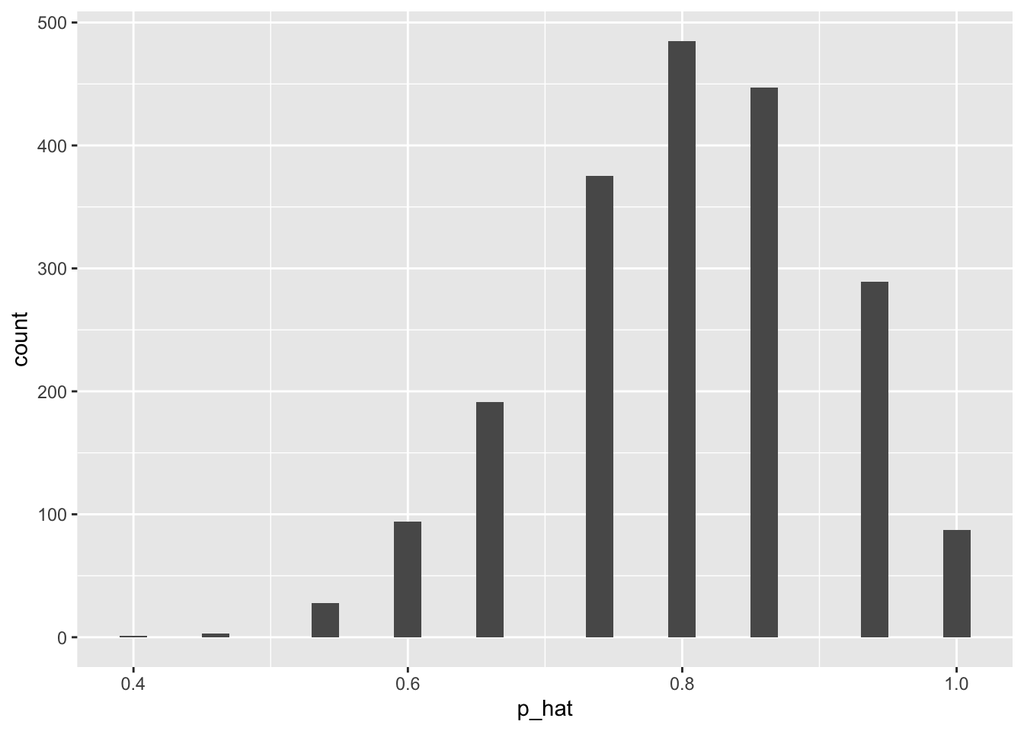

```r
ggplot(data = sample_props15, aes(x = p_hat)) +
  geom_histogram(binwidth = 0.02)
```

1. Change your sample size from 15 to 150, then compute the sampling distribution using the same method as above, and store these proportions in a new object called `sample_props150`. Describe the shape of this sampling distribution and compare it to the sampling distribution for a sample size of 15. Based on this sampling distribution, what would you guess to be the true proportion of those who think the work scientists do enhances their lives?

   Answer: From the histogram, the true proportion would be that 80% responded that the work scientists do does enhance their lives. Success-failure condition - (150 x .8) = 120 and 150(1 - .8) = 30. The shape is symmetrical and bell shaped and resembles a normal distribution.

```r
(sample_props150 <- global_monitor %>%
                    rep_sample_n(size = 150, reps = 2000, replace = TRUE) %>%
                    count(scientist_work) %>%
                    mutate(p_hat = n /sum(n)) %>%
                    filter(scientist_work == "Benefits"))
```

```
## # A tibble: 2,000 x 4
## # Groups:   replicate [2,000]
##    replicate scientist_work     n p_hat
##        <int> <chr>          <int> <dbl>
##  1         1 Benefits         120 0.8
##  2         2 Benefits         127 0.847
##  3         3 Benefits         122 0.813
##  4         4 Benefits         116 0.773
##  5         5 Benefits         123 0.82
##  6         6 Benefits         122 0.813
##  7         7 Benefits         126 0.84
##  8         8 Benefits         119 0.793
##  9         9 Benefits         120 0.8
## 10        10 Benefits         114 0.76
## # … with 1,990 more rows
```

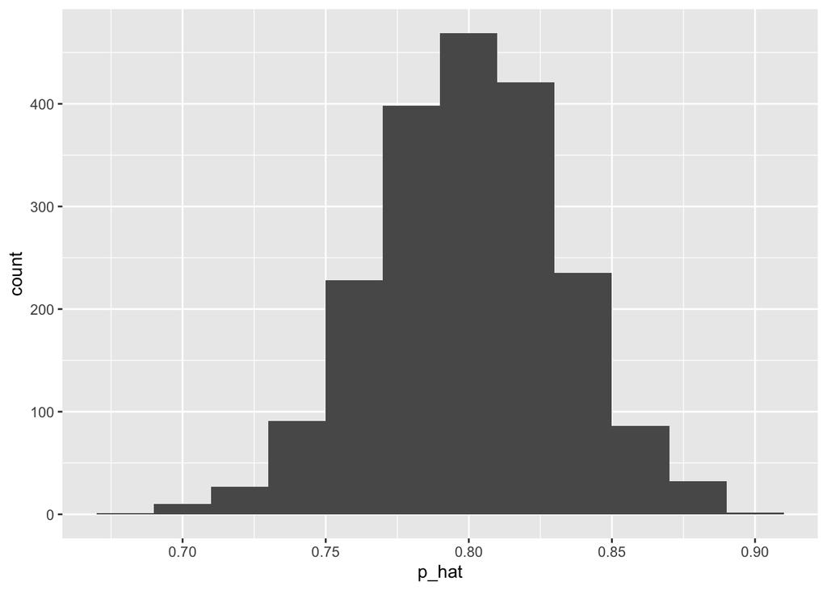

```r
ggplot(data = sample_props150, aes(x = p_hat)) +
  geom_histogram(binwidth = 0.02)
```

1. Of the sampling distributions from 2 and 3, which has a smaller spread? If you’re concerned with making estimates that are more often close to the true value, would you prefer a sampling distribution with a large or small spread? Answer: The sampling distribution from 2 has a wider spread than 3. If I’m concerned with making estimates that are more often close to the true value, I would prefer a small spread.